# Risk Factor Analysis

## Outcome Variable

**Outcome Variable:** ever_swasted

## Predictor Variables

**Intervention Variable:** birthlen

**Adjustment Set:**

unadjusted

## Stratifying Variables

The analysis was stratified on these variable(s):

- agecat
- studyid
- country

## Data Summary

| agecat | studyid | country | birthlen | ever_swasted | n_cell | n |
| --- | --- | --- | --- | --- | --- | --- |
| 0-24 months (no birth wast) | ki0047075b-MAL-ED | BANGLADESH | >=50 cm | 0 | 26 | 254 |
| 0-24 months (no birth wast) | ki0047075b-MAL-ED | BANGLADESH | >=50 cm | 1 | 3 | 254 |
| 0-24 months (no birth wast) | ki0047075b-MAL-ED | BANGLADESH | <48 cm | 0 | 134 | 254 |
| 0-24 months (no birth wast) | ki0047075b-MAL-ED | BANGLADESH | <48 cm | 1 | 6 | 254 |
| 0-24 months (no birth wast) | ki0047075b-MAL-ED | BANGLADESH | [48-50) cm | 0 | 82 | 254 |
| 0-24 months (no birth wast) | ki0047075b-MAL-ED | BANGLADESH | [48-50) cm | 1 | 3 | 254 |
| 0-24 months (no birth wast) | ki0047075b-MAL-ED | BRAZIL | >=50 cm | 0 | 32 | 188 |
| 0-24 months (no birth wast) | ki0047075b-MAL-ED | BRAZIL | >=50 cm | 1 | 2 | 188 |
| 0-24 months (no birth wast) | ki0047075b-MAL-ED | BRAZIL | <48 cm | 0 | 78 | 188 |
| 0-24 months (no birth wast) | ki0047075b-MAL-ED | BRAZIL | <48 cm | 1 | 0 | 188 |
| 0-24 months (no birth wast) | ki0047075b-MAL-ED | BRAZIL | [48-50) cm | 0 | 75 | 188 |
| 0-24 months (no birth wast) | ki0047075b-MAL-ED | BRAZIL | [48-50) cm | 1 | 1 | 188 |
| 0-24 months (no birth wast) | ki0047075b-MAL-ED | INDIA | >=50 cm | 0 | 24 | 199 |
| 0-24 months (no birth wast) | ki0047075b-MAL-ED | INDIA | >=50 cm | 1 | 1 | 199 |
| 0-24 months (no birth wast) | ki0047075b-MAL-ED | INDIA | <48 cm | 0 | 101 | 199 |
| 0-24 months (no birth wast) | ki0047075b-MAL-ED | INDIA | <48 cm | 1 | 3 | 199 |
| 0-24 months (no birth wast) | ki0047075b-MAL-ED | INDIA | [48-50) cm | 0 | 67 | 199 |
| 0-24 months (no birth wast) | ki0047075b-MAL-ED | INDIA | [48-50) cm | 1 | 3 | 199 |
| 0-24 months (no birth wast) | ki0047075b-MAL-ED | NEPAL | >=50 cm | 0 | 38 | 172 |
| 0-24 months (no birth wast) | ki0047075b-MAL-ED | NEPAL | >=50 cm | 1 | 0 | 172 |
| 0-24 months (no birth wast) | ki0047075b-MAL-ED | NEPAL | <48 cm | 0 | 68 | 172 |
| 0-24 months (no birth wast) | ki0047075b-MAL-ED | NEPAL | <48 cm | 1 | 0 | 172 |
| 0-24 months (no birth wast) | ki0047075b-MAL-ED | NEPAL | [48-50) cm | 0 | 66 | 172 |
| 0-24 months (no birth wast) | ki0047075b-MAL-ED | NEPAL | [48-50) cm | 1 | 0 | 172 |
| 0-24 months (no birth wast) | ki0047075b-MAL-ED | PERU | >=50 cm | 0 | 32 | 285 |
| 0-24 months (no birth wast) | ki0047075b-MAL-ED | PERU | >=50 cm | 1 | 1 | 285 |
| 0-24 months (no birth wast) | ki0047075b-MAL-ED | PERU | <48 cm | 0 | 139 | 285 |
| 0-24 months (no birth wast) | ki0047075b-MAL-ED | PERU | <48 cm | 1 | 2 | 285 |
| 0-24 months (no birth wast) | ki0047075b-MAL-ED | PERU | [48-50) cm | 0 | 111 | 285 |
| 0-24 months (no birth wast) | ki0047075b-MAL-ED | PERU | [48-50) cm | 1 | 0 | 285 |

[output cut: 474 more lines]

The following strata were considered:

- agecat: 0-24 months (no birth wast), studyid: ki0047075b-MAL-ED, country: BANGLADESH
- agecat: 0-24 months (no birth wast), studyid: ki0047075b-MAL-ED, country: BRAZIL
- agecat: 0-24 months (no birth wast), studyid: ki0047075b-MAL-ED, country: INDIA
- agecat: 0-24 months (no birth wast), studyid: ki0047075b-MAL-ED, country: NEPAL
- agecat: 0-24 months (no birth wast), studyid: ki0047075b-MAL-ED, country: PERU
- agecat: 0-24 months (no birth wast), studyid: ki0047075b-MAL-ED, country: SOUTH AFRICA
- agecat: 0-24 months (no birth wast), studyid: ki0047075b-MAL-ED, country: TANZANIA, UNITED REPUBLIC OF
- agecat: 0-24 months (no birth wast), studyid: ki1000108-CMC-V-BCS-2002, country: INDIA
- agecat: 0-24 months (no birth wast), studyid: ki1000108-IRC, country: INDIA
- agecat: 0-24 months (no birth wast), studyid: ki1000109-EE, country: PAKISTAN
- agecat: 0-24 months (no birth wast), studyid: ki1000109-ResPak, country: PAKISTAN
- agecat: 0-24 months (no birth wast), studyid: ki1000304b-SAS-CompFeed, country: INDIA
- agecat: 0-24 months (no birth wast), studyid: ki1017093-NIH-Birth, country: BANGLADESH
- agecat: 0-24 months (no birth wast), studyid: ki1017093b-PROVIDE, country: BANGLADESH
- agecat: 0-24 months (no birth wast), studyid: ki1017093c-NIH-Crypto, country: BANGLADESH
- agecat: 0-24 months (no birth wast), studyid: ki1101329-Keneba, country: GAMBIA
- agecat: 0-24 months (no birth wast), studyid: ki1114097-CMIN, country: BANGLADESH
- agecat: 0-24 months (no birth wast), studyid: ki1114097-CMIN, country: BRAZIL
- agecat: 0-24 months (no birth wast), studyid: ki1114097-CMIN, country: GUINEA-BISSAU
- agecat: 0-24 months (no birth wast), studyid: ki1114097-CMIN, country: PERU
- agecat: 0-24 months (no birth wast), studyid: ki1114097-CONTENT, country: PERU
- agecat: 0-24 months (no birth wast), studyid: ki1119695-PROBIT, country: BELARUS
- agecat: 0-24 months (no birth wast), studyid: ki1126311-ZVITAMBO, country: ZIMBABWE
- agecat: 0-24 months (no birth wast), studyid: ki1135781-COHORTS, country: GUATEMALA
- agecat: 0-24 months (no birth wast), studyid: ki1135781-COHORTS, country: INDIA
- agecat: 0-24 months (no birth wast), studyid: ki1135781-COHORTS, country: PHILIPPINES
- agecat: 0-24 months (no birth wast), studyid: kiGH5241-JiVitA-3, country: BANGLADESH
- agecat: 0-24 months (no birth wast), studyid: kiGH5241-JiVitA-4, country: BANGLADESH
- agecat: 0-6 months (no birth wast), studyid: ki0047075b-MAL-ED, country: BANGLADESH
- agecat: 0-6 months (no birth wast), studyid: ki0047075b-MAL-ED, country: BRAZIL
- agecat: 0-6 months (no birth wast), studyid: ki0047075b-MAL-ED, country: INDIA
- agecat: 0-6 months (no birth wast), studyid: ki0047075b-MAL-ED, country: NEPAL
- agecat: 0-6 months (no birth wast), studyid: ki0047075b-MAL-ED, country: PERU
- agecat: 0-6 months (no birth wast), studyid: ki0047075b-MAL-ED, country: SOUTH AFRICA
- agecat: 0-6 months (no birth wast), studyid: ki0047075b-MAL-ED, country: TANZANIA, UNITED REPUBLIC OF
- agecat: 0-6 months (no birth wast), studyid: ki1000108-CMC-V-BCS-2002, country: INDIA
- agecat: 0-6 months (no birth wast), studyid: ki1000108-IRC, country: INDIA
- agecat: 0-6 months (no birth wast), studyid: ki1000109-EE, country: PAKISTAN
- agecat: 0-6 months (no birth wast), studyid: ki1000109-ResPak, country: PAKISTAN
- agecat: 0-6 months (no birth wast), studyid: ki1000304b-SAS-CompFeed, country: INDIA
- agecat: 0-6 months (no birth wast), studyid: ki1017093-NIH-Birth, country: BANGLADESH
- agecat: 0-6 months (no birth wast), studyid: ki1017093b-PROVIDE, country: BANGLADESH
- agecat: 0-6 months (no birth wast), studyid: ki1017093c-NIH-Crypto, country: BANGLADESH
- agecat: 0-6 months (no birth wast), studyid: ki1101329-Keneba, country: GAMBIA
- agecat: 0-6 months (no birth wast), studyid: ki1114097-CMIN, country: BANGLADESH
- agecat: 0-6 months (no birth wast), studyid: ki1114097-CMIN, country: BRAZIL
- agecat: 0-6 months (no birth wast), studyid: ki1114097-CMIN, country: GUINEA-BISSAU
- agecat: 0-6 months (no birth wast), studyid: ki1114097-CMIN, country: PERU
- agecat: 0-6 months (no birth wast), studyid: ki1114097-CONTENT, country: PERU
- agecat: 0-6 months (no birth wast), studyid: ki1119695-PROBIT, country: BELARUS
- agecat: 0-6 months (no birth wast), studyid: ki1126311-ZVITAMBO, country: ZIMBABWE
- agecat: 0-6 months (no birth wast), studyid: ki1135781-COHORTS, country: GUATEMALA
- agecat: 0-6 months (no birth wast), studyid: ki1135781-COHORTS, country: INDIA
- agecat: 0-6 months (no birth wast), studyid: ki1135781-COHORTS, country: PHILIPPINES
- agecat: 0-6 months (no birth wast), studyid: kiGH5241-JiVitA-3, country: BANGLADESH
- agecat: 0-6 months (no birth wast), studyid: kiGH5241-JiVitA-4, country: BANGLADESH
- agecat: 6-24 months, studyid: ki0047075b-MAL-ED, country: BANGLADESH
- agecat: 6-24 months, studyid: ki0047075b-MAL-ED, country: BRAZIL
- agecat: 6-24 months, studyid: ki0047075b-MAL-ED, country: INDIA
- agecat: 6-24 months, studyid: ki0047075b-MAL-ED, country: NEPAL
- agecat: 6-24 months, studyid: ki0047075b-MAL-ED, country: PERU
- agecat: 6-24 months, studyid: ki0047075b-MAL-ED, country: SOUTH AFRICA
- agecat: 6-24 months, studyid: ki0047075b-MAL-ED, country: TANZANIA, UNITED REPUBLIC OF
- agecat: 6-24 months, studyid: ki1000108-CMC-V-BCS-2002, country: INDIA
- agecat: 6-24 months, studyid: ki1000108-IRC, country: INDIA
- agecat: 6-24 months, studyid: ki1000109-EE, country: PAKISTAN
- agecat: 6-24 months, studyid: ki1000109-ResPak, country: PAKISTAN
- agecat: 6-24 months, studyid: ki1000304b-SAS-CompFeed, country: INDIA
- agecat: 6-24 months, studyid: ki1017093-NIH-Birth, country: BANGLADESH
- agecat: 6-24 months, studyid: ki1017093b-PROVIDE, country: BANGLADESH
- agecat: 6-24 months, studyid: ki1017093c-NIH-Crypto, country: BANGLADESH
- agecat: 6-24 months, studyid: ki1101329-Keneba, country: GAMBIA
- agecat: 6-24 months, studyid: ki1114097-CMIN, country: BANGLADESH
- agecat: 6-24 months, studyid: ki1114097-CMIN, country: BRAZIL
- agecat: 6-24 months, studyid: ki1114097-CMIN, country: GUINEA-BISSAU
- agecat: 6-24 months, studyid: ki1114097-CMIN, country: PERU
- agecat: 6-24 months, studyid: ki1114097-CONTENT, country: PERU
- agecat: 6-24 months, studyid: ki1119695-PROBIT, country: BELARUS
- agecat: 6-24 months, studyid: ki1126311-ZVITAMBO, country: ZIMBABWE
- agecat: 6-24 months, studyid: ki1135781-COHORTS, country: GUATEMALA
- agecat: 6-24 months, studyid: ki1135781-COHORTS, country: INDIA
- agecat: 6-24 months, studyid: ki1135781-COHORTS, country: PHILIPPINES
- agecat: 6-24 months, studyid: kiGH5241-JiVitA-3, country: BANGLADESH
- agecat: 6-24 months, studyid: kiGH5241-JiVitA-4, country: BANGLADESH

### Dropped Strata

Some strata were dropped due to rare outcomes:

- agecat: 0-24 months (no birth wast), studyid: ki0047075b-MAL-ED, country: BANGLADESH
- agecat: 0-24 months (no birth wast), studyid: ki0047075b-MAL-ED, country: BRAZIL
- agecat: 0-24 months (no birth wast), studyid: ki0047075b-MAL-ED, country: INDIA
- agecat: 0-24 months (no birth wast), studyid: ki0047075b-MAL-ED, country: NEPAL
- agecat: 0-24 months (no birth wast), studyid: ki0047075b-MAL-ED, country: PERU
- agecat: 0-24 months (no birth wast), studyid: ki0047075b-MAL-ED, country: SOUTH AFRICA
- agecat: 0-24 months (no birth wast), studyid: ki0047075b-MAL-ED, country: TANZANIA, UNITED REPUBLIC OF
- agecat: 0-24 months (no birth wast), studyid: ki1000108-CMC-V-BCS-2002, country: INDIA
- agecat: 0-24 months (no birth wast), studyid: ki1000109-EE, country: PAKISTAN
- agecat: 0-24 months (no birth wast), studyid: ki1000109-ResPak, country: PAKISTAN
- agecat: 0-24 months (no birth wast), studyid: ki1000304b-SAS-CompFeed, country: INDIA
- agecat: 0-24 months (no birth wast), studyid: ki1017093-NIH-Birth, country: BANGLADESH
- agecat: 0-24 months (no birth wast), studyid: ki1017093b-PROVIDE, country: BANGLADESH
- agecat: 0-24 months (no birth wast), studyid: ki1017093c-NIH-Crypto, country: BANGLADESH
- agecat: 0-24 months (no birth wast), studyid: ki1114097-CMIN, country: BANGLADESH
- agecat: 0-24 months (no birth wast), studyid: ki1114097-CMIN, country: BRAZIL
- agecat: 0-24 months (no birth wast), studyid: ki1114097-CMIN, country: GUINEA-BISSAU
- agecat: 0-24 months (no birth wast), studyid: ki1114097-CMIN, country: PERU
- agecat: 0-24 months (no birth wast), studyid: ki1114097-CONTENT, country: PERU
- agecat: 0-24 months (no birth wast), studyid: ki1119695-PROBIT, country: BELARUS
- agecat: 0-24 months (no birth wast), studyid: ki1135781-COHORTS, country: GUATEMALA
- agecat: 0-6 months (no birth wast), studyid: ki0047075b-MAL-ED, country: BANGLADESH
- agecat: 0-6 months (no birth wast), studyid: ki0047075b-MAL-ED, country: BRAZIL
- agecat: 0-6 months (no birth wast), studyid: ki0047075b-MAL-ED, country: INDIA
- agecat: 0-6 months (no birth wast), studyid: ki0047075b-MAL-ED, country: NEPAL
- agecat: 0-6 months (no birth wast), studyid: ki0047075b-MAL-ED, country: PERU
- agecat: 0-6 months (no birth wast), studyid: ki0047075b-MAL-ED, country: SOUTH AFRICA
- agecat: 0-6 months (no birth wast), studyid: ki0047075b-MAL-ED, country: TANZANIA, UNITED REPUBLIC OF
- agecat: 0-6 months (no birth wast), studyid: ki1000108-CMC-V-BCS-2002, country: INDIA
- agecat: 0-6 months (no birth wast), studyid: ki1000109-EE, country: PAKISTAN
- agecat: 0-6 months (no birth wast), studyid: ki1000109-ResPak, country: PAKISTAN
- agecat: 0-6 months (no birth wast), studyid: ki1000304b-SAS-CompFeed, country: INDIA
- agecat: 0-6 months (no birth wast), studyid: ki1017093-NIH-Birth, country: BANGLADESH
- agecat: 0-6 months (no birth wast), studyid: ki1017093b-PROVIDE, country: BANGLADESH
- agecat: 0-6 months (no birth wast), studyid: ki1017093c-NIH-Crypto, country: BANGLADESH
- agecat: 0-6 months (no birth wast), studyid: ki1114097-CMIN, country: BANGLADESH
- agecat: 0-6 months (no birth wast), studyid: ki1114097-CMIN, country: BRAZIL
- agecat: 0-6 months (no birth wast), studyid: ki1114097-CMIN, country: GUINEA-BISSAU
- agecat: 0-6 months (no birth wast), studyid: ki1114097-CMIN, country: PERU
- agecat: 0-6 months (no birth wast), studyid: ki1114097-CONTENT, country: PERU
- agecat: 0-6 months (no birth wast), studyid: ki1119695-PROBIT, country: BELARUS
- agecat: 0-6 months (no birth wast), studyid: ki1135781-COHORTS, country: GUATEMALA
- agecat: 0-6 months (no birth wast), studyid: kiGH5241-JiVitA-4, country: BANGLADESH
- agecat: 6-24 months, studyid: ki0047075b-MAL-ED, country: BANGLADESH
- agecat: 6-24 months, studyid: ki0047075b-MAL-ED, country: BRAZIL
- agecat: 6-24 months, studyid: ki0047075b-MAL-ED, country: INDIA
- agecat: 6-24 months, studyid: ki0047075b-MAL-ED, country: NEPAL
- agecat: 6-24 months, studyid: ki0047075b-MAL-ED, country: PERU
- agecat: 6-24 months, studyid: ki0047075b-MAL-ED, country: SOUTH AFRICA
- agecat: 6-24 months, studyid: ki0047075b-MAL-ED, country: TANZANIA, UNITED REPUBLIC OF
- agecat: 6-24 months, studyid: ki1000108-CMC-V-BCS-2002, country: INDIA
- agecat: 6-24 months, studyid: ki1000109-EE, country: PAKISTAN
- agecat: 6-24 months, studyid: ki1000109-ResPak, country: PAKISTAN
- agecat: 6-24 months, studyid: ki1000304b-SAS-CompFeed, country: INDIA
- agecat: 6-24 months, studyid: ki1017093-NIH-Birth, country: BANGLADESH
- agecat: 6-24 months, studyid: ki1017093b-PROVIDE, country: BANGLADESH
- agecat: 6-24 months, studyid: ki1017093c-NIH-Crypto, country: BANGLADESH
- agecat: 6-24 months, studyid: ki1114097-CMIN, country: BANGLADESH
- agecat: 6-24 months, studyid: ki1114097-CMIN, country: BRAZIL
- agecat: 6-24 months, studyid: ki1114097-CMIN, country: GUINEA-BISSAU
- agecat: 6-24 months, studyid: ki1114097-CMIN, country: PERU
- agecat: 6-24 months, studyid: ki1114097-CONTENT, country: PERU
- agecat: 6-24 months, studyid: ki1119695-PROBIT, country: BELARUS
- agecat: 6-24 months, studyid: ki1135781-COHORTS, country: GUATEMALA

## Methods Detail

We’re interested in the causal parameters $E[Y_a]$ for all values of $a \in \mathcal{A}$. These parameters represent the mean outcome if, possibly contrary to fact, we intervened to set all units to have $A=a$. Under the randomization and positivity assumptions, these are identified by the statistical parameters $\psi_a=E_W[E_{Y|A,W}(Y|A=a,W)]$. In addition, we’re interested in the mean of $Y$, $E[Y]$ under no intervention (the observed mean). We will estimate these parameters by using SuperLearner to fit the relevant likelihood factors – $E_{Y|A,W}(Y|A=a,W)$ and $p(A=a|W)$, and then updating our likelihood fit using a joint TMLE.

For unadjusted analyses ($W=\{\}$), initial likelihoods were estimated using Lrnr_glm to estimate the simple $E(Y|A)$ and Lrnr_mean to estimate $p(A)$. For adjusted analyses, a small library containing Lrnr_glmnet, Lrnr_xgboost, and Lrnr_mean was used.

Having estimated these parameters, we will then use the delta method to estimate relative risks and attributable risks relative to a prespecified baseline level of $A$.

# Results Detail

## Results Plots

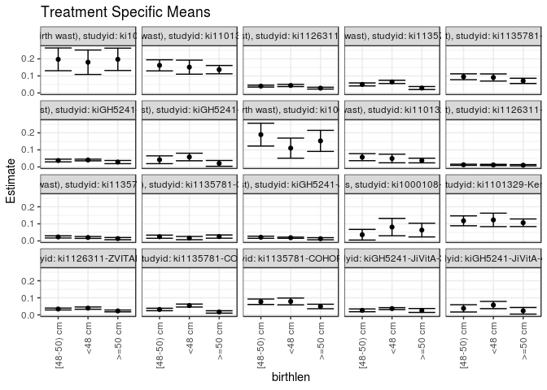

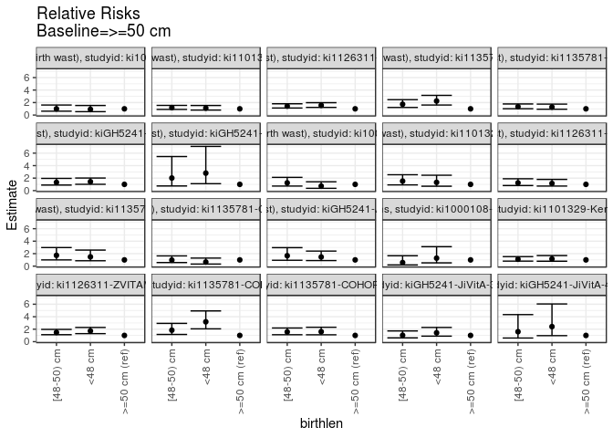

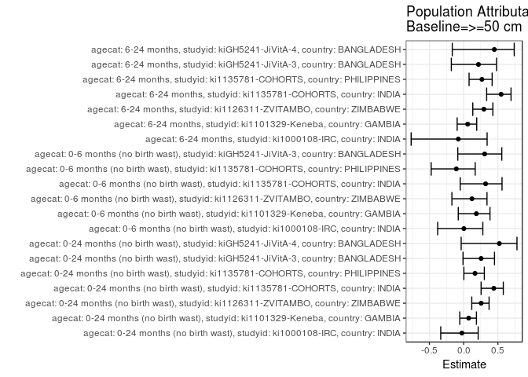

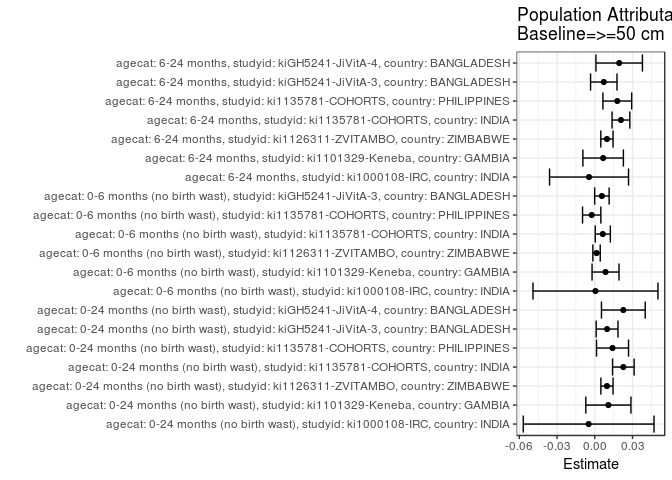

## Results Table

### Parameter: TSM

| agecat | studyid | country | intervention_level | baseline_level | estimate | ci_lower | ci_upper |
| --- | --- | --- | --- | --- | --- | --- | --- |
| 0-24 months (no birth wast) | ki1000108-IRC | INDIA | >=50 cm | NA | 0.1971831 | 0.1316585 | 0.2627077 |
| 0-24 months (no birth wast) | ki1000108-IRC | INDIA | <48 cm | NA | 0.1801802 | 0.1085894 | 0.2517709 |
| 0-24 months (no birth wast) | ki1000108-IRC | INDIA | [48-50) cm | NA | 0.1970803 | 0.1303838 | 0.2637768 |
| 0-24 months (no birth wast) | ki1101329-Keneba | GAMBIA | >=50 cm | NA | 0.1366623 | 0.1122499 | 0.1610747 |
| 0-24 months (no birth wast) | ki1101329-Keneba | GAMBIA | <48 cm | NA | 0.1512027 | 0.1100287 | 0.1923768 |
| 0-24 months (no birth wast) | ki1101329-Keneba | GAMBIA | [48-50) cm | NA | 0.1619433 | 0.1294463 | 0.1944403 |
| 0-24 months (no birth wast) | ki1126311-ZVITAMBO | ZIMBABWE | >=50 cm | NA | 0.0282002 | 0.0228050 | 0.0335953 |
| 0-24 months (no birth wast) | ki1126311-ZVITAMBO | ZIMBABWE | <48 cm | NA | 0.0439533 | 0.0375489 | 0.0503576 |
| 0-24 months (no birth wast) | ki1126311-ZVITAMBO | ZIMBABWE | [48-50) cm | NA | 0.0402431 | 0.0346663 | 0.0458200 |
| 0-24 months (no birth wast) | ki1135781-COHORTS | INDIA | >=50 cm | NA | 0.0288600 | 0.0200457 | 0.0376744 |
| 0-24 months (no birth wast) | ki1135781-COHORTS | INDIA | <48 cm | NA | 0.0649203 | 0.0555103 | 0.0743303 |
| 0-24 months (no birth wast) | ki1135781-COHORTS | INDIA | [48-50) cm | NA | 0.0500000 | 0.0412063 | 0.0587937 |
| 0-24 months (no birth wast) | ki1135781-COHORTS | PHILIPPINES | >=50 cm | NA | 0.0708372 | 0.0555832 | 0.0860912 |
| 0-24 months (no birth wast) | ki1135781-COHORTS | PHILIPPINES | <48 cm | NA | 0.0906593 | 0.0697988 | 0.1115199 |
| 0-24 months (no birth wast) | ki1135781-COHORTS | PHILIPPINES | [48-50) cm | NA | 0.0949821 | 0.0777777 | 0.1121865 |
| 0-24 months (no birth wast) | kiGH5241-JiVitA-3 | BANGLADESH | >=50 cm | NA | 0.0284775 | 0.0191702 | 0.0377849 |
| 0-24 months (no birth wast) | kiGH5241-JiVitA-3 | BANGLADESH | <48 cm | NA | 0.0406484 | 0.0357768 | 0.0455201 |
| 0-24 months (no birth wast) | kiGH5241-JiVitA-3 | BANGLADESH | [48-50) cm | NA | 0.0375465 | 0.0296285 | 0.0454644 |
| 0-24 months (no birth wast) | kiGH5241-JiVitA-4 | BANGLADESH | >=50 cm | NA | 0.0208333 | 0.0037874 | 0.0378793 |
| 0-24 months (no birth wast) | kiGH5241-JiVitA-4 | BANGLADESH | <48 cm | NA | 0.0582878 | 0.0361702 | 0.0804054 |
| 0-24 months (no birth wast) | kiGH5241-JiVitA-4 | BANGLADESH | [48-50) cm | NA | 0.0419580 | 0.0191218 | 0.0647943 |
| 0-6 months (no birth wast) | ki1000108-IRC | INDIA | >=50 cm | NA | 0.1526718 | 0.0909978 | 0.2143458 |
| 0-6 months (no birth wast) | ki1000108-IRC | INDIA | <48 cm | NA | 0.1100917 | 0.0512522 | 0.1689313 |
| 0-6 months (no birth wast) | ki1000108-IRC | INDIA | [48-50) cm | NA | 0.1893939 | 0.1224620 | 0.2563259 |
| 0-6 months (no birth wast) | ki1101329-Keneba | GAMBIA | >=50 cm | NA | 0.0375839 | 0.0239225 | 0.0512453 |
| 0-6 months (no birth wast) | ki1101329-Keneba | GAMBIA | <48 cm | NA | 0.0494700 | 0.0241973 | 0.0747427 |
| 0-6 months (no birth wast) | ki1101329-Keneba | GAMBIA | [48-50) cm | NA | 0.0572597 | 0.0366602 | 0.0778593 |
| 0-6 months (no birth wast) | ki1126311-ZVITAMBO | ZIMBABWE | >=50 cm | NA | 0.0101614 | 0.0067631 | 0.0135597 |
| 0-6 months (no birth wast) | ki1126311-ZVITAMBO | ZIMBABWE | <48 cm | NA | 0.0116408 | 0.0081407 | 0.0151409 |
| 0-6 months (no birth wast) | ki1126311-ZVITAMBO | ZIMBABWE | [48-50) cm | NA | 0.0125829 | 0.0092783 | 0.0158875 |
| 0-6 months (no birth wast) | ki1135781-COHORTS | INDIA | >=50 cm | NA | 0.0135028 | 0.0071270 | 0.0198785 |
| 0-6 months (no birth wast) | ki1135781-COHORTS | INDIA | <48 cm | NA | 0.0200984 | 0.0145273 | 0.0256695 |
| 0-6 months (no birth wast) | ki1135781-COHORTS | INDIA | [48-50) cm | NA | 0.0233196 | 0.0169941 | 0.0296452 |
| 0-6 months (no birth wast) | ki1135781-COHORTS | PHILIPPINES | >=50 cm | NA | 0.0253046 | 0.0158797 | 0.0347295 |
| 0-6 months (no birth wast) | ki1135781-COHORTS | PHILIPPINES | <48 cm | NA | 0.0166436 | 0.0073038 | 0.0259833 |
| 0-6 months (no birth wast) | ki1135781-COHORTS | PHILIPPINES | [48-50) cm | NA | 0.0245678 | 0.0154139 | 0.0337217 |
| 0-6 months (no birth wast) | kiGH5241-JiVitA-3 | BANGLADESH | >=50 cm | NA | 0.0127849 | 0.0066415 | 0.0189282 |
| 0-6 months (no birth wast) | kiGH5241-JiVitA-3 | BANGLADESH | <48 cm | NA | 0.0187385 | 0.0153614 | 0.0221156 |
| 0-6 months (no birth wast) | kiGH5241-JiVitA-3 | BANGLADESH | [48-50) cm | NA | 0.0213563 | 0.0151735 | 0.0275391 |
| 6-24 months | ki1000108-IRC | INDIA | >=50 cm | NA | 0.0633803 | 0.0232549 | 0.1035056 |
| 6-24 months | ki1000108-IRC | INDIA | <48 cm | NA | 0.0810811 | 0.0302369 | 0.1319252 |
| 6-24 months | ki1000108-IRC | INDIA | [48-50) cm | NA | 0.0362319 | 0.0050145 | 0.0674493 |
| 6-24 months | ki1101329-Keneba | GAMBIA | >=50 cm | NA | 0.1063257 | 0.0841535 | 0.1284979 |
| 6-24 months | ki1101329-Keneba | GAMBIA | <48 cm | NA | 0.1231343 | 0.0837809 | 0.1624878 |
| 6-24 months | ki1101329-Keneba | GAMBIA | [48-50) cm | NA | 0.1176471 | 0.0886935 | 0.1466006 |
| 6-24 months | ki1126311-ZVITAMBO | ZIMBABWE | >=50 cm | NA | 0.0230643 | 0.0177236 | 0.0284049 |
| 6-24 months | ki1126311-ZVITAMBO | ZIMBABWE | <48 cm | NA | 0.0395630 | 0.0329980 | 0.0461281 |
| 6-24 months | ki1126311-ZVITAMBO | ZIMBABWE | [48-50) cm | NA | 0.0342334 | 0.0286997 | 0.0397670 |
| 6-24 months | ki1135781-COHORTS | INDIA | >=50 cm | NA | 0.0171386 | 0.0101941 | 0.0240831 |
| 6-24 months | ki1135781-COHORTS | INDIA | <48 cm | NA | 0.0545954 | 0.0457699 | 0.0634210 |
| 6-24 months | ki1135781-COHORTS | INDIA | [48-50) cm | NA | 0.0315651 | 0.0243895 | 0.0387407 |
| 6-24 months | ki1135781-COHORTS | PHILIPPINES | >=50 cm | NA | 0.0491803 | 0.0360165 | 0.0623441 |
| 6-24 months | ki1135781-COHORTS | PHILIPPINES | <48 cm | NA | 0.0786838 | 0.0587205 | 0.0986472 |
| 6-24 months | ki1135781-COHORTS | PHILIPPINES | [48-50) cm | NA | 0.0769231 | 0.0609240 | 0.0929221 |
| 6-24 months | kiGH5241-JiVitA-3 | BANGLADESH | >=50 cm | NA | 0.0258549 | 0.0143136 | 0.0373962 |
| 6-24 months | kiGH5241-JiVitA-3 | BANGLADESH | <48 cm | NA | 0.0367756 | 0.0310730 | 0.0424783 |
| 6-24 months | kiGH5241-JiVitA-3 | BANGLADESH | [48-50) cm | NA | 0.0265487 | 0.0183763 | 0.0347210 |
| 6-24 months | kiGH5241-JiVitA-4 | BANGLADESH | >=50 cm | NA | 0.0238806 | 0.0046308 | 0.0431304 |
| 6-24 months | kiGH5241-JiVitA-4 | BANGLADESH | <48 cm | NA | 0.0576577 | 0.0364632 | 0.0788521 |
| 6-24 months | kiGH5241-JiVitA-4 | BANGLADESH | [48-50) cm | NA | 0.0381944 | 0.0167939 | 0.0595950 |

### Parameter: E(Y)

| agecat | studyid | country | intervention_level | baseline_level | estimate | ci_lower | ci_upper |
| --- | --- | --- | --- | --- | --- | --- | --- |
| 0-24 months (no birth wast) | ki1000108-IRC | INDIA | NA | NA | 0.1923077 | 0.1531430 | 0.2314724 |
| 0-24 months (no birth wast) | ki1101329-Keneba | GAMBIA | NA | NA | 0.1474774 | 0.1297967 | 0.1651581 |
| 0-24 months (no birth wast) | ki1126311-ZVITAMBO | ZIMBABWE | NA | NA | 0.0378935 | 0.0345223 | 0.0412647 |
| 0-24 months (no birth wast) | ki1135781-COHORTS | INDIA | NA | NA | 0.0515674 | 0.0461404 | 0.0569944 |
| 0-24 months (no birth wast) | ki1135781-COHORTS | PHILIPPINES | NA | NA | 0.0849539 | 0.0748584 | 0.0950494 |
| 0-24 months (no birth wast) | kiGH5241-JiVitA-3 | BANGLADESH | NA | NA | 0.0382569 | 0.0343814 | 0.0421325 |
| 0-24 months (no birth wast) | kiGH5241-JiVitA-4 | BANGLADESH | NA | NA | 0.0435525 | 0.0313774 | 0.0557276 |
| 0-6 months (no birth wast) | ki1000108-IRC | INDIA | NA | NA | 0.1532258 | 0.1165727 | 0.1898789 |
| 0-6 months (no birth wast) | ki1101329-Keneba | GAMBIA | NA | NA | 0.0461437 | 0.0355829 | 0.0567045 |
| 0-6 months (no birth wast) | ki1126311-ZVITAMBO | ZIMBABWE | NA | NA | 0.0115673 | 0.0095979 | 0.0135367 |
| 0-6 months (no birth wast) | ki1135781-COHORTS | INDIA | NA | NA | 0.0198844 | 0.0163171 | 0.0234518 |
| 0-6 months (no birth wast) | ki1135781-COHORTS | PHILIPPINES | NA | NA | 0.0228611 | 0.0174082 | 0.0283140 |
| 0-6 months (no birth wast) | kiGH5241-JiVitA-3 | BANGLADESH | NA | NA | 0.0184438 | 0.0156672 | 0.0212203 |
| 6-24 months | ki1000108-IRC | INDIA | NA | NA | 0.0588235 | 0.0354714 | 0.0821757 |
| 6-24 months | ki1101329-Keneba | GAMBIA | NA | NA | 0.1129792 | 0.0968836 | 0.1290747 |
| 6-24 months | ki1126311-ZVITAMBO | ZIMBABWE | NA | NA | 0.0327342 | 0.0293418 | 0.0361265 |
| 6-24 months | ki1135781-COHORTS | INDIA | NA | NA | 0.0379316 | 0.0331642 | 0.0426990 |
| 6-24 months | ki1135781-COHORTS | PHILIPPINES | NA | NA | 0.0670949 | 0.0578297 | 0.0763601 |
| 6-24 months | kiGH5241-JiVitA-3 | BANGLADESH | NA | NA | 0.0330116 | 0.0286477 | 0.0373755 |
| 6-24 months | kiGH5241-JiVitA-4 | BANGLADESH | NA | NA | 0.0432937 | 0.0313994 | 0.0551881 |

### Parameter: RR

| agecat | studyid | country | intervention_level | baseline_level | estimate | ci_lower | ci_upper |
| --- | --- | --- | --- | --- | --- | --- | --- |
| 0-24 months (no birth wast) | ki1000108-IRC | INDIA | >=50 cm | >=50 cm | 1.0000000 | 1.0000000 | 1.000000 |
| 0-24 months (no birth wast) | ki1000108-IRC | INDIA | <48 cm | >=50 cm | 0.9137709 | 0.5443581 | 1.533875 |
| 0-24 months (no birth wast) | ki1000108-IRC | INDIA | [48-50) cm | >=50 cm | 0.9994786 | 0.6219992 | 1.606043 |
| 0-24 months (no birth wast) | ki1101329-Keneba | GAMBIA | >=50 cm | >=50 cm | 1.0000000 | 1.0000000 | 1.000000 |
| 0-24 months (no birth wast) | ki1101329-Keneba | GAMBIA | <48 cm | >=50 cm | 1.1063970 | 0.7988644 | 1.532318 |
| 0-24 months (no birth wast) | ki1101329-Keneba | GAMBIA | [48-50) cm | >=50 cm | 1.1849891 | 0.9058099 | 1.550214 |
| 0-24 months (no birth wast) | ki1126311-ZVITAMBO | ZIMBABWE | >=50 cm | >=50 cm | 1.0000000 | 1.0000000 | 1.000000 |
| 0-24 months (no birth wast) | ki1126311-ZVITAMBO | ZIMBABWE | <48 cm | >=50 cm | 1.5586168 | 1.2254570 | 1.982351 |
| 0-24 months (no birth wast) | ki1126311-ZVITAMBO | ZIMBABWE | [48-50) cm | >=50 cm | 1.4270532 | 1.1267959 | 1.807320 |
| 0-24 months (no birth wast) | ki1135781-COHORTS | INDIA | >=50 cm | >=50 cm | 1.0000000 | 1.0000000 | 1.000000 |
| 0-24 months (no birth wast) | ki1135781-COHORTS | INDIA | <48 cm | >=50 cm | 2.2494875 | 1.6042170 | 3.154308 |
| 0-24 months (no birth wast) | ki1135781-COHORTS | INDIA | [48-50) cm | >=50 cm | 1.7325000 | 1.2179014 | 2.464532 |
| 0-24 months (no birth wast) | ki1135781-COHORTS | PHILIPPINES | >=50 cm | >=50 cm | 1.0000000 | 1.0000000 | 1.000000 |
| 0-24 months (no birth wast) | ki1135781-COHORTS | PHILIPPINES | <48 cm | >=50 cm | 1.2798273 | 0.9338686 | 1.753949 |
| 0-24 months (no birth wast) | ki1135781-COHORTS | PHILIPPINES | [48-50) cm | >=50 cm | 1.3408509 | 1.0119861 | 1.776587 |
| 0-24 months (no birth wast) | kiGH5241-JiVitA-3 | BANGLADESH | >=50 cm | >=50 cm | 1.0000000 | 1.0000000 | 1.000000 |
| 0-24 months (no birth wast) | kiGH5241-JiVitA-3 | BANGLADESH | <48 cm | >=50 cm | 1.4273856 | 1.0134735 | 2.010343 |
| 0-24 months (no birth wast) | kiGH5241-JiVitA-3 | BANGLADESH | [48-50) cm | >=50 cm | 1.3184587 | 0.8882263 | 1.957084 |
| 0-24 months (no birth wast) | kiGH5241-JiVitA-4 | BANGLADESH | >=50 cm | >=50 cm | 1.0000000 | 1.0000000 | 1.000000 |
| 0-24 months (no birth wast) | kiGH5241-JiVitA-4 | BANGLADESH | <48 cm | >=50 cm | 2.7978142 | 1.1060241 | 7.077390 |
| 0-24 months (no birth wast) | kiGH5241-JiVitA-4 | BANGLADESH | [48-50) cm | >=50 cm | 2.0139860 | 0.7432113 | 5.457586 |
| 0-6 months (no birth wast) | ki1000108-IRC | INDIA | >=50 cm | >=50 cm | 1.0000000 | 1.0000000 | 1.000000 |
| 0-6 months (no birth wast) | ki1000108-IRC | INDIA | <48 cm | >=50 cm | 0.7211009 | 0.3690116 | 1.409133 |
| 0-6 months (no birth wast) | ki1000108-IRC | INDIA | [48-50) cm | >=50 cm | 1.2405303 | 0.7252843 | 2.121810 |
| 0-6 months (no birth wast) | ki1101329-Keneba | GAMBIA | >=50 cm | >=50 cm | 1.0000000 | 1.0000000 | 1.000000 |
| 0-6 months (no birth wast) | ki1101329-Keneba | GAMBIA | <48 cm | >=50 cm | 1.3162544 | 0.7031412 | 2.463980 |
| 0-6 months (no birth wast) | ki1101329-Keneba | GAMBIA | [48-50) cm | >=50 cm | 1.5235174 | 0.9135674 | 2.540705 |
| 0-6 months (no birth wast) | ki1126311-ZVITAMBO | ZIMBABWE | >=50 cm | >=50 cm | 1.0000000 | 1.0000000 | 1.000000 |
| 0-6 months (no birth wast) | ki1126311-ZVITAMBO | ZIMBABWE | <48 cm | >=50 cm | 1.1455915 | 0.7306624 | 1.796151 |
| 0-6 months (no birth wast) | ki1126311-ZVITAMBO | ZIMBABWE | [48-50) cm | >=50 cm | 1.2383086 | 0.8093852 | 1.894535 |
| 0-6 months (no birth wast) | ki1135781-COHORTS | INDIA | >=50 cm | >=50 cm | 1.0000000 | 1.0000000 | 1.000000 |
| 0-6 months (no birth wast) | ki1135781-COHORTS | INDIA | <48 cm | >=50 cm | 1.4884669 | 0.8608943 | 2.573526 |
| 0-6 months (no birth wast) | ki1135781-COHORTS | INDIA | [48-50) cm | >=50 cm | 1.7270233 | 1.0018520 | 2.977096 |
| 0-6 months (no birth wast) | ki1135781-COHORTS | PHILIPPINES | >=50 cm | >=50 cm | 1.0000000 | 1.0000000 | 1.000000 |
| 0-6 months (no birth wast) | ki1135781-COHORTS | PHILIPPINES | <48 cm | >=50 cm | 0.6577285 | 0.3353833 | 1.289888 |
| 0-6 months (no birth wast) | ki1135781-COHORTS | PHILIPPINES | [48-50) cm | >=50 cm | 0.9708826 | 0.5732790 | 1.644248 |
| 0-6 months (no birth wast) | kiGH5241-JiVitA-3 | BANGLADESH | >=50 cm | >=50 cm | 1.0000000 | 1.0000000 | 1.000000 |
| 0-6 months (no birth wast) | kiGH5241-JiVitA-3 | BANGLADESH | <48 cm | >=50 cm | 1.4656780 | 0.8908535 | 2.411409 |
| 0-6 months (no birth wast) | kiGH5241-JiVitA-3 | BANGLADESH | [48-50) cm | >=50 cm | 1.6704351 | 0.9417822 | 2.962844 |
| 6-24 months | ki1000108-IRC | INDIA | >=50 cm | >=50 cm | 1.0000000 | 1.0000000 | 1.000000 |
| 6-24 months | ki1000108-IRC | INDIA | <48 cm | >=50 cm | 1.2792793 | 0.5247750 | 3.118585 |
| 6-24 months | ki1000108-IRC | INDIA | [48-50) cm | >=50 cm | 0.5716586 | 0.1962438 | 1.665243 |
| 6-24 months | ki1101329-Keneba | GAMBIA | >=50 cm | >=50 cm | 1.0000000 | 1.0000000 | 1.000000 |
| 6-24 months | ki1101329-Keneba | GAMBIA | <48 cm | >=50 cm | 1.1580861 | 0.7906947 | 1.696184 |
| 6-24 months | ki1101329-Keneba | GAMBIA | [48-50) cm | >=50 cm | 1.1064780 | 0.8014037 | 1.527687 |
| 6-24 months | ki1126311-ZVITAMBO | ZIMBABWE | >=50 cm | >=50 cm | 1.0000000 | 1.0000000 | 1.000000 |
| 6-24 months | ki1126311-ZVITAMBO | ZIMBABWE | <48 cm | >=50 cm | 1.7153402 | 1.2901224 | 2.280708 |
| 6-24 months | ki1126311-ZVITAMBO | ZIMBABWE | [48-50) cm | >=50 cm | 1.4842609 | 1.1190982 | 1.968576 |
| 6-24 months | ki1135781-COHORTS | INDIA | >=50 cm | >=50 cm | 1.0000000 | 1.0000000 | 1.000000 |
| 6-24 months | ki1135781-COHORTS | INDIA | <48 cm | >=50 cm | 3.1855253 | 2.0592980 | 4.927685 |
| 6-24 months | ki1135781-COHORTS | INDIA | [48-50) cm | >=50 cm | 1.8417550 | 1.1573229 | 2.930955 |
| 6-24 months | ki1135781-COHORTS | PHILIPPINES | >=50 cm | >=50 cm | 1.0000000 | 1.0000000 | 1.000000 |
| 6-24 months | ki1135781-COHORTS | PHILIPPINES | <48 cm | >=50 cm | 1.5999046 | 1.1064322 | 2.313467 |
| 6-24 months | ki1135781-COHORTS | PHILIPPINES | [48-50) cm | >=50 cm | 1.5641026 | 1.1144256 | 2.195227 |
| 6-24 months | kiGH5241-JiVitA-3 | BANGLADESH | >=50 cm | >=50 cm | 1.0000000 | 1.0000000 | 1.000000 |
| 6-24 months | kiGH5241-JiVitA-3 | BANGLADESH | <48 cm | >=50 cm | 1.4223865 | 0.8871231 | 2.280612 |
| 6-24 months | kiGH5241-JiVitA-3 | BANGLADESH | [48-50) cm | >=50 cm | 1.0268341 | 0.6116247 | 1.723914 |
| 6-24 months | kiGH5241-JiVitA-4 | BANGLADESH | >=50 cm | >=50 cm | 1.0000000 | 1.0000000 | 1.000000 |
| 6-24 months | kiGH5241-JiVitA-4 | BANGLADESH | <48 cm | >=50 cm | 2.4144144 | 0.9645124 | 6.043880 |
| 6-24 months | kiGH5241-JiVitA-4 | BANGLADESH | [48-50) cm | >=50 cm | 1.5993924 | 0.5899713 | 4.335899 |

### Parameter: PAR

| agecat | studyid | country | intervention_level | baseline_level | estimate | ci_lower | ci_upper |
| --- | --- | --- | --- | --- | --- | --- | --- |
| 0-24 months (no birth wast) | ki1000108-IRC | INDIA | >=50 cm | NA | -0.0048754 | -0.0568448 | 0.0470940 |
| 0-24 months (no birth wast) | ki1101329-Keneba | GAMBIA | >=50 cm | NA | 0.0108151 | -0.0071254 | 0.0287555 |
| 0-24 months (no birth wast) | ki1126311-ZVITAMBO | ZIMBABWE | >=50 cm | NA | 0.0096934 | 0.0048574 | 0.0145294 |
| 0-24 months (no birth wast) | ki1135781-COHORTS | INDIA | >=50 cm | NA | 0.0227074 | 0.0141406 | 0.0312741 |
| 0-24 months (no birth wast) | ki1135781-COHORTS | PHILIPPINES | >=50 cm | NA | 0.0141168 | 0.0013883 | 0.0268453 |
| 0-24 months (no birth wast) | kiGH5241-JiVitA-3 | BANGLADESH | >=50 cm | NA | 0.0097794 | 0.0011189 | 0.0184399 |
| 0-24 months (no birth wast) | kiGH5241-JiVitA-4 | BANGLADESH | >=50 cm | NA | 0.0227192 | 0.0053293 | 0.0401091 |
| 0-6 months (no birth wast) | ki1000108-IRC | INDIA | >=50 cm | NA | 0.0005541 | -0.0491269 | 0.0502350 |
| 0-6 months (no birth wast) | ki1101329-Keneba | GAMBIA | >=50 cm | NA | 0.0085598 | -0.0021571 | 0.0192767 |
| 0-6 months (no birth wast) | ki1126311-ZVITAMBO | ZIMBABWE | >=50 cm | NA | 0.0014059 | -0.0015272 | 0.0043390 |
| 0-6 months (no birth wast) | ki1135781-COHORTS | INDIA | >=50 cm | NA | 0.0063817 | 0.0003833 | 0.0123800 |
| 0-6 months (no birth wast) | ki1135781-COHORTS | PHILIPPINES | >=50 cm | NA | -0.0024435 | -0.0097169 | 0.0048299 |
| 0-6 months (no birth wast) | kiGH5241-JiVitA-3 | BANGLADESH | >=50 cm | NA | 0.0056589 | -0.0000914 | 0.0114092 |
| 6-24 months | ki1000108-IRC | INDIA | >=50 cm | NA | -0.0045568 | -0.0359562 | 0.0268427 |
| 6-24 months | ki1101329-Keneba | GAMBIA | >=50 cm | NA | 0.0066534 | -0.0094523 | 0.0227592 |
| 6-24 months | ki1126311-ZVITAMBO | ZIMBABWE | >=50 cm | NA | 0.0096699 | 0.0048067 | 0.0145331 |
| 6-24 months | ki1135781-COHORTS | INDIA | >=50 cm | NA | 0.0207930 | 0.0137239 | 0.0278621 |
| 6-24 months | ki1135781-COHORTS | PHILIPPINES | >=50 cm | NA | 0.0179146 | 0.0064749 | 0.0293543 |
| 6-24 months | kiGH5241-JiVitA-3 | BANGLADESH | >=50 cm | NA | 0.0071567 | -0.0033533 | 0.0176667 |
| 6-24 months | kiGH5241-JiVitA-4 | BANGLADESH | >=50 cm | NA | 0.0194131 | 0.0009294 | 0.0378968 |

### Parameter: PAF

| agecat | studyid | country | intervention_level | baseline_level | estimate | ci_lower | ci_upper |
| --- | --- | --- | --- | --- | --- | --- | --- |
| 0-24 months (no birth wast) | ki1000108-IRC | INDIA | >=50 cm | NA | -0.0253521 | -0.3345184 | 0.2121900 |
| 0-24 months (no birth wast) | ki1101329-Keneba | GAMBIA | >=50 cm | NA | 0.0733338 | -0.0564145 | 0.1871465 |
| 0-24 months (no birth wast) | ki1126311-ZVITAMBO | ZIMBABWE | >=50 cm | NA | 0.2558055 | 0.1188702 | 0.3714598 |
| 0-24 months (no birth wast) | ki1135781-COHORTS | INDIA | >=50 cm | NA | 0.4403435 | 0.2552053 | 0.5794608 |
| 0-24 months (no birth wast) | ki1135781-COHORTS | PHILIPPINES | >=50 cm | NA | 0.1661697 | 0.0033566 | 0.3023855 |
| 0-24 months (no birth wast) | kiGH5241-JiVitA-3 | BANGLADESH | >=50 cm | NA | 0.2556237 | -0.0091800 | 0.4509443 |
| 0-24 months (no birth wast) | kiGH5241-JiVitA-4 | BANGLADESH | >=50 cm | NA | 0.5216503 | -0.0360694 | 0.7791476 |
| 0-6 months (no birth wast) | ki1000108-IRC | INDIA | >=50 cm | NA | 0.0036159 | -0.3795908 | 0.2803799 |
| 0-6 months (no birth wast) | ki1101329-Keneba | GAMBIA | >=50 cm | NA | 0.1855034 | -0.0784642 | 0.3848616 |
| 0-6 months (no birth wast) | ki1126311-ZVITAMBO | ZIMBABWE | >=50 cm | NA | 0.1215442 | -0.1713048 | 0.3411753 |
| 0-6 months (no birth wast) | ki1135781-COHORTS | INDIA | >=50 cm | NA | 0.3209371 | -0.0504827 | 0.5610338 |
| 0-6 months (no birth wast) | ki1135781-COHORTS | PHILIPPINES | >=50 cm | NA | -0.1068842 | -0.4741878 | 0.1689033 |
| 0-6 months (no birth wast) | kiGH5241-JiVitA-3 | BANGLADESH | >=50 cm | NA | 0.3068180 | -0.0853617 | 0.5572893 |
| 6-24 months | ki1000108-IRC | INDIA | >=50 cm | NA | -0.0774648 | -0.7670506 | 0.3430124 |
| 6-24 months | ki1101329-Keneba | GAMBIA | >=50 cm | NA | 0.0588909 | -0.0948091 | 0.1910131 |
| 6-24 months | ki1126311-ZVITAMBO | ZIMBABWE | >=50 cm | NA | 0.2954071 | 0.1337538 | 0.4268938 |
| 6-24 months | ki1135781-COHORTS | INDIA | >=50 cm | NA | 0.5481708 | 0.3364341 | 0.6923446 |
| 6-24 months | ki1135781-COHORTS | PHILIPPINES | >=50 cm | NA | 0.2670038 | 0.0795803 | 0.4162626 |
| 6-24 months | kiGH5241-JiVitA-3 | BANGLADESH | >=50 cm | NA | 0.2167932 | -0.1796891 | 0.4800216 |
| 6-24 months | kiGH5241-JiVitA-4 | BANGLADESH | >=50 cm | NA | 0.4484050 | -0.1661346 | 0.7390893 |